# Examen práctico — Módulo 2

### Materia: Laboratorio de Aprendizaje Estadístico

### Profesor: Antonio Manguart Paez

### Alumna: Maria Fernanda Gómez Flores

## Instrucciones

Realiza un modelo de clasificación para predecir la variable respuesta del dataset asignado.

Tu entrega debe incluir:

1. Una breve exploración de datos, especialmente contra la variable respuesta.
2. División de datos en entrenamiento y prueba: 80% train / 20% test.
3. Aplicación de los modelos de clasificación vistos en clase.
4. Cálculo y comparación del AUC de cada modelo.
5. Un intento razonable por mejorar el AUC.
6. Una breve conclusión indicando:
   - qué modelo funcionó mejor,
   - qué AUC obtuvo,
   - qué decisiones ayudaron a mejorar el resultado.

Se evaluará el flujo completo: exploración, preparación, modelado, evaluación e interpretación.

## Preparación de datos

```python
import warnings
warnings.filterwarnings("ignore")

import pandas as pd
import numpy as np
import matplotlib.pyplot as plt
from sklearn import linear_model
```

```python
df = pd.read_csv('diabetes.csv')
df.head()
```

|  | gender | age | hypertension | heart_disease | smoking_history | bmi | diabetes |
| --- | --- | --- | --- | --- | --- | --- | --- |
| 0 | Female | 80.0 | 0 | 1 | never | 25.19 | 0 |
| 1 | Female | 54.0 | 0 | 0 | No Info | 27.32 | 0 |
| 2 | Male | 28.0 | 0 | 0 | never | 27.32 | 0 |
| 3 | Female | 36.0 | 0 | 0 | current | 23.45 | 0 |
| 4 | Male | 76.0 | 1 | 1 | current | 20.14 | 0 |

```python
df.isna().mean()
```

```
gender             0.0
age                0.0
hypertension       0.0
heart_disease      0.0
smoking_history    0.0
bmi                0.0
diabetes           0.0
dtype: float64
```

```python
df = df.fillna(df.mean(numeric_only=True))
```

```python
df.isna().mean()
```

```
gender             0.0
age                0.0
hypertension       0.0
heart_disease      0.0
smoking_history    0.0
bmi                0.0
diabetes           0.0
dtype: float64
```

### Conclusión de preparación

Primero revise el dataset y no hay valores faltantes en ninguna variable, entonces no fue necesario eliminar ni imputar observaciones.

Tambien identifique que gender y smoking_history son categoricas, mientras que age, hypertension, heart_disease y bmi son numericas. Por eso mas adelante convierto las categoricas a dummies antes de entrenar los modelos.

## Exploración de datos

```python
df.diabetes.mean()
```

```
np.float64(0.085)
```

El target es diabetes, donde 1 significa que la persona tiene diabetes y 0 que no tiene.

El promedio del target fue 0.085, entonces solamente 8.5% de las observaciones pertenecen a la clase 1. Esto muestra que el target esta bastante desbalanceado, por eso tiene sentido comparar los modelos con AUC y no solamente con accuracy.

```python
df.groupby('diabetes').mean(numeric_only=True)
```

| diabetes | age | hypertension | heart_disease | bmi |
| --- | --- | --- | --- | --- |
| 0 | 40.115187 | 0.058984 | 0.029235 | 26.887163 |
| 1 | 60.946588 | 0.245647 | 0.149059 | 31.988382 |

Al comparar los promedios se ven diferencias claras entre las dos clases.

Las personas con diabetes tienen una edad promedio de 60.95 años contra 40.12 en las personas sin diabetes. Tambien tienen mayor proporcion de hipertension 24.56% vs 5.90%, enfermedad del corazon 14.91% vs 2.92% y un BMI promedio mayor 31.99 vs 26.89.

Entonces estas variables si parecen aportar informacion para separar a las personas con diabetes de las que no tienen.

```python
df.groupby('gender').diabetes.mean()
```

```
gender
Female    0.076189
Male      0.097490
Other     0.000000
Name: diabetes, dtype: float64
```

```python
df.groupby('smoking_history').diabetes.mean()
```

```
smoking_history
No Info        0.040596
current        0.102089
ever           0.117882
former         0.170017
never          0.095341
not current    0.107027
Name: diabetes, dtype: float64
```

Tambien revise las variables categoricas contra diabetes.

En gender, la proporcion de diabetes fue de 9.75% en hombres y 7.62% en mujeres.

En smoking_history, la proporcion mas alta aparece en former con aproximadamente 17.00%, mientras que No Info tiene alrededor de 4.06%.

Esto muestra que las variables categoricas tambien tienen diferencias entre grupos, por lo que vale la pena incluirlas en los modelos despues de convertirlas a dummies.

## Target

```python
y = df['diabetes']

X = df.copy()
del X['diabetes']
```

gender y smoking_history son categoricas entonces las convierto a dummies

```python
categoricas = [
    'gender',
    'smoking_history'
]
```

```python
X = pd.get_dummies(X, columns=categoricas)
```

```python
X.head()
```

|  | age | hypertension | heart_disease | bmi | gender_Female | gender_Male | gender_Other | smoking_history_No Info | smoking_history_current | smoking_history_ever | smoking_history_former | smoking_history_never | smoking_history_not current |
| --- | --- | --- | --- | --- | --- | --- | --- | --- | --- | --- | --- | --- | --- |
| 0 | 80.0 | 0 | 1 | 25.19 | True | False | False | False | False | False | False | True | False |
| 1 | 54.0 | 0 | 0 | 27.32 | True | False | False | True | False | False | False | False | False |
| 2 | 28.0 | 0 | 0 | 27.32 | False | True | False | False | False | False | False | True | False |
| 3 | 36.0 | 0 | 0 | 23.45 | True | False | False | False | True | False | False | False | False |
| 4 | 76.0 | 1 | 1 | 20.14 | False | True | False | False | True | False | False | False | False |

## Train / Test

```python
from sklearn.model_selection import train_test_split

X_train, X_test, y_train, y_test = train_test_split(
    X, y, test_size=0.2, stratify=y, random_state=42
)
```

Dividi los datos en 80% entrenamiento y 20% prueba, como pide el examen.

Use stratify=y para mantener aproximadamente la misma proporcion de diabetes en train y test, lo cual es importante porque el target esta desbalanceado.

## Regresión Logística

```python
from sklearn.linear_model import LogisticRegression
```

```python
model_logistica = LogisticRegression(max_iter=2000)
model_logistica.fit(X_train,y_train)
```

```
LogisticRegression(max_iter=2000)
```

```python
probabilidades_logistica = model_logistica.predict_proba(X_test)[:,1]
probabilidades_logistica
```

```
array([0.01999936, 0.02301267, 0.05576908, ..., 0.02963295, 0.10590034,
       0.123958  ])
```

```python
from sklearn.metrics import roc_auc_score

auc_logistica = roc_auc_score(y_score=probabilidades_logistica, y_true=y_test)
auc_logistica
```

```
np.float64(0.8379282545805208)
```

```python
from sklearn.metrics import roc_curve

fpr_logistica, tpr_logistica, umbrales = roc_curve(
    y_true=y_test,
    y_score=probabilidades_logistica
)
```

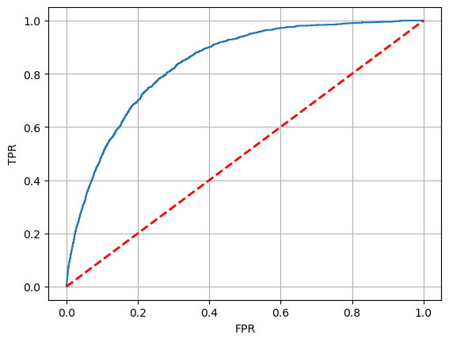

```python
plt.plot(fpr_logistica,tpr_logistica)
plt.plot([0, 1], [0, 1], color='red', linestyle='--', lw=2, label='Clasificador aleatorio')
plt.xlabel("FPR")
plt.ylabel("TPR")
plt.grid()
```

La regresion logistica obtuvo un AUC de 0.8379.

Esto quiere decir que el modelo logra separar bastante bien a las personas con diabetes de las que no tienen y me sirve como una buena referencia para comparar los demas modelos.

## KNN

```python
from sklearn.neighbors import KNeighborsClassifier
from sklearn.preprocessing import StandardScaler
from sklearn.pipeline import Pipeline
```

```python
model_knn = Pipeline([
    ('scaler', StandardScaler()),
    ('model', KNeighborsClassifier(n_neighbors=5))
])

model_knn.fit(X_train,y_train)
```

```
Pipeline(steps=[('scaler', StandardScaler()),
                ('model', KNeighborsClassifier())])
```

```python
probabilidades_knn = model_knn.predict_proba(X_test)[:,1]
probabilidades_knn
```

```
array([0., 0., 0., ..., 0., 0., 0.])
```

```python
auc_knn = roc_auc_score(y_score=probabilidades_knn, y_true=y_test)
auc_knn
```

```
np.float64(0.7035451783992286)
```

```python
fpr_knn, tpr_knn, umbrales = roc_curve(
    y_true=y_test,
    y_score=probabilidades_knn
)
```

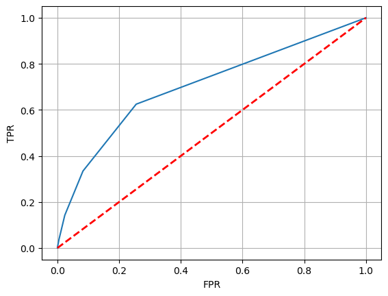

```python
plt.plot(fpr_knn,tpr_knn)
plt.plot([0, 1], [0, 1], color='red', linestyle='--', lw=2, label='Clasificador aleatorio')
plt.xlabel("FPR")
plt.ylabel("TPR")
plt.grid()
```

En KNN use StandardScaler porque el modelo trabaja con distancias y asi ninguna variable pesa mas solamente por tener valores mas grandes.

Con 5 vecinos obtuvo un AUC de 0.7035, que es bastante menor que el de la regresion logistica. Entonces con esta configuracion KNN no parece ser el mejor modelo para estos datos.

## Polinomial

```python
from sklearn.preprocessing import PolynomialFeatures
from sklearn.preprocessing import StandardScaler
from sklearn.pipeline import Pipeline
from sklearn.model_selection import GridSearchCV
```

```python
pipeline = Pipeline([
    ('poly', PolynomialFeatures()),
    ('scaler', StandardScaler()),
    ('model', linear_model.LogisticRegression())
])
```

```python
params = {
    'poly__degree': [1,2]
}
```

```python
grid = GridSearchCV(
    estimator=pipeline,
    param_grid=params,
    scoring='roc_auc',
    cv=5
)
```

```python
grid.fit(X_train,y_train)
```

```
GridSearchCV(cv=5,
             estimator=Pipeline(steps=[('poly', PolynomialFeatures()),
                                       ('scaler', StandardScaler()),
                                       ('model', LogisticRegression())]),
             param_grid={'poly__degree': [1, 2]}, scoring='roc_auc')
```

```python
grid.best_params_
```

```
{'poly__degree': 2}
```

```python
probabilidades_poly = grid.predict_proba(X_test)[:,1]
probabilidades_poly
```

```
array([0.01581558, 0.01676509, 0.05236958, ..., 0.02522618, 0.08552532,
       0.11908221])
```

```python
auc_poly = roc_auc_score(y_score=probabilidades_poly, y_true=y_test)
auc_poly
```

```
np.float64(0.8402026036644167)
```

```python
fpr_poly, tpr_poly, umbrales = roc_curve(
    y_true=y_test,
    y_score=probabilidades_poly
)
```

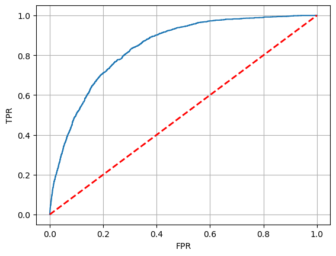

```python
plt.plot(fpr_poly,tpr_poly)
plt.plot([0, 1], [0, 1], color='red', linestyle='--', lw=2, label='Clasificador aleatorio')
plt.xlabel("FPR")
plt.ylabel("TPR")
plt.grid()
```

En el modelo polinomial use cross validation para comparar grados 1 y 2 y el mejor fue grado 2.

El modelo obtuvo un AUC de 0.8402, ligeramente mayor que la regresion logistica. Esto indica que agregar relaciones de grado 2 entre las variables si mejoro un poco la capacidad de separar las dos clases.

## Ridge

```python
model_ridge = Pipeline([
    ('scaler', StandardScaler()),
    ('model', linear_model.LogisticRegression(penalty='l2'))
])

model_ridge.fit(X_train,y_train)
```

```
Pipeline(steps=[('scaler', StandardScaler()), ('model', LogisticRegression())])
```

```python
probabilidades_ridge = model_ridge.predict_proba(X_test)[:,1]
probabilidades_ridge
```

```
array([0.01988978, 0.02293254, 0.05598907, ..., 0.02953891, 0.10577688,
       0.12403573])
```

```python
auc_ridge = roc_auc_score(y_score=probabilidades_ridge, y_true=y_test)
auc_ridge
```

```
np.float64(0.8379898746383799)
```

```python
fpr_ridge, tpr_ridge, umbrales = roc_curve(
    y_true=y_test,
    y_score=probabilidades_ridge
)
```

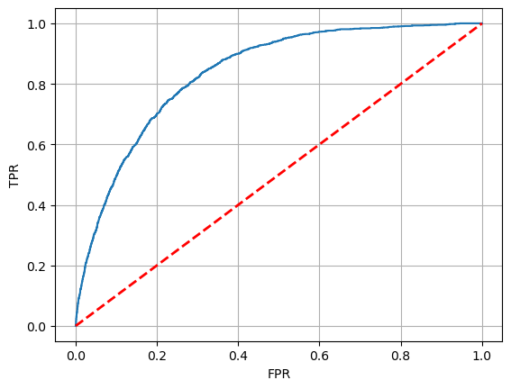

```python
plt.plot(fpr_ridge,tpr_ridge)
plt.plot([0, 1], [0, 1], color='red', linestyle='--', lw=2, label='Clasificador aleatorio')
plt.xlabel("FPR")
plt.ylabel("TPR")
plt.grid()
```

Ridge obtuvo un AUC de 0.8380.

El resultado es practicamente igual al de la regresion logistica 0.8379, por lo que la penalizacion L2 no genero una mejora importante en este caso.

## LDA

```python
from sklearn.discriminant_analysis import LinearDiscriminantAnalysis
```

```python
pipeline_lda = Pipeline([
    ("scaler", StandardScaler()),
    ("lda", LinearDiscriminantAnalysis())
])

pipeline_lda.fit(X_train, y_train)
```

```
Pipeline(steps=[('scaler', StandardScaler()),
                ('lda', LinearDiscriminantAnalysis())])
```

```python
probabilidades_lda = pipeline_lda.predict_proba(X_test)[:,1]
```

```python
auc_lda = roc_auc_score(y_score=probabilidades_lda, y_true=y_test)
auc_lda
```

```
np.float64(0.8307843137254902)
```

```python
fpr_lda, tpr_lda, umbrales = roc_curve(
    y_true=y_test,
    y_score=probabilidades_lda
)
```

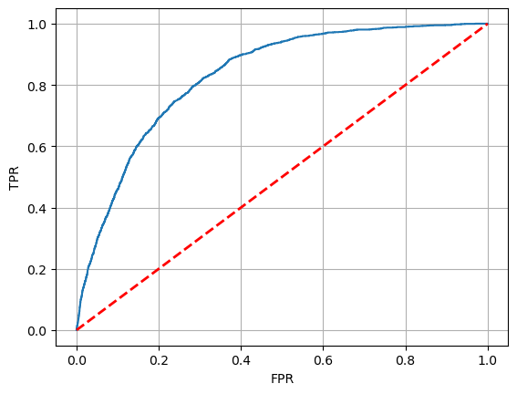

```python
plt.plot(fpr_lda,tpr_lda)
plt.plot([0, 1], [0, 1], color='red', linestyle='--', lw=2, label='Clasificador aleatorio')
plt.xlabel("FPR")
plt.ylabel("TPR")
plt.grid()
```

LDA obtuvo un AUC de 0.8308.

El modelo logra separar bastante bien las clases, pero su AUC fue menor que el de la regresion logistica, Ridge y el modelo polinomial, entonces no fue el mejor de los modelos probados.

## Red neuronal

```python
from sklearn.neural_network import MLPClassifier
```

```python
pipeline_red = Pipeline([
    ('scaler', StandardScaler()),
    ('mlp', MLPClassifier(
        max_iter=500000,
        early_stopping=True,
        n_iter_no_change=20,
        random_state=42
    ))
])

param_grid = {
    'mlp__hidden_layer_sizes': [(10,), (20,), (20,10)],
    'mlp__alpha': [0.001, 0.1],
    'mlp__activation': ['relu', 'tanh'],
}

grid_red = GridSearchCV(
    pipeline_red,
    param_grid,
    scoring='roc_auc',
    cv=3,
    n_jobs=-1
)

grid_red.fit(X_train, y_train)
```

```
GridSearchCV(cv=3,
             estimator=Pipeline(steps=[('scaler', StandardScaler()),
                                       ('mlp',
                                        MLPClassifier(early_stopping=True,
                                                      max_iter=500000,
                                                      n_iter_no_change=20,
                                                      random_state=42))]),
             n_jobs=-1,
             param_grid={'mlp__activation': ['relu', 'tanh'],
                         'mlp__alpha': [0.001, 0.1],
                         'mlp__hidden_layer_sizes': [(10,), (20,), (20, 10)]},
             scoring='roc_auc')
```

```python
grid_red.best_params_
```

```
{'mlp__activation': 'relu',
 'mlp__alpha': 0.1,
 'mlp__hidden_layer_sizes': (20, 10)}
```

```python
probabilidades_red = grid_red.best_estimator_.predict_proba(X_test)[:, 1]

auc_red = roc_auc_score(y_test, probabilidades_red)
auc_red
```

```
np.float64(0.8395613629058181)
```

```python
fpr_red, tpr_red, umbrales = roc_curve(
    y_true=y_test,
    y_score=probabilidades_red
)
```

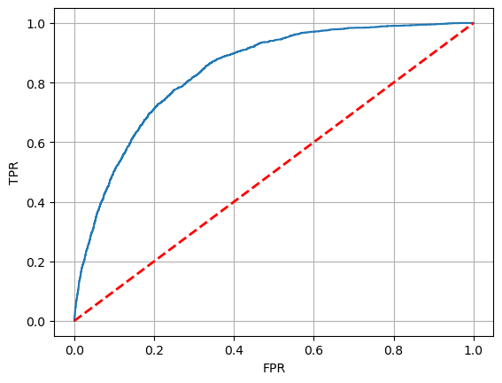

```python
plt.plot(fpr_red,tpr_red)
plt.plot([0, 1], [0, 1], color='red', linestyle='--', lw=2, label='Clasificador aleatorio')
plt.xlabel("FPR")
plt.ylabel("TPR")
plt.grid()
```

En la red neuronal use StandardScaler y GridSearchCV para probar diferentes capas ocultas, alpha y funciones de activacion.

La mejor combinacion fue ReLU, alpha = 0.1 y capas 20, 10. Con esta configuracion la red obtuvo un AUC de 0.8396.

El resultado fue muy cercano al modelo polinomial, pero quedo ligeramente por debajo.

## Comparación de modelos

```python
resultados = pd.DataFrame({
    'Modelo': [
        'Regresión Logística',
        'KNN',
        'Polinomial',
        'Ridge',
        'LDA',
        'Red neuronal'
    ],
    'AUC': [
        auc_logistica,
        auc_knn,
        auc_poly,
        auc_ridge,
        auc_lda,
        auc_red
    ]
})

resultados = resultados.sort_values(by='AUC',ascending=False)
resultados
```

|  | Modelo | AUC |
| --- | --- | --- |
| 2 | Polinomial | 0.840203 |
| 5 | Red neuronal | 0.839561 |
| 3 | Ridge | 0.837990 |
| 0 | Regresión Logística | 0.837928 |
| 4 | LDA | 0.830784 |
| 1 | KNN | 0.703545 |

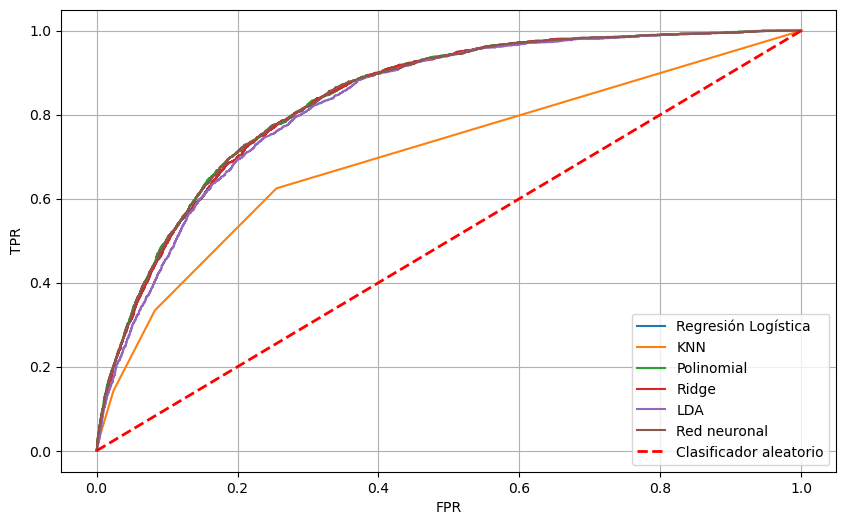

```python
plt.figure(figsize=(10,6))

plt.plot(fpr_logistica,tpr_logistica,label="Regresión Logística")
plt.plot(fpr_knn,tpr_knn,label="KNN")
plt.plot(fpr_poly,tpr_poly,label="Polinomial")
plt.plot(fpr_ridge,tpr_ridge,label="Ridge")
plt.plot(fpr_lda,tpr_lda,label="LDA")
plt.plot(fpr_red,tpr_red,label="Red neuronal")

plt.plot([0, 1], [0, 1], color='red', linestyle='--', lw=2, label='Clasificador aleatorio')
plt.xlabel("FPR")
plt.ylabel("TPR")
plt.legend()
plt.grid()
```

Al comparar todos los modelos usando el mismo conjunto de prueba, el polinomial fue el mejor con AUC de 0.8402.

Despues quedaron la red neuronal con 0.8396, Ridge con 0.8380, regresion logistica con 0.8379, LDA con 0.8308 y KNN con 0.7035.

Las diferencias entre los primeros cuatro modelos son pequeñas, pero el polinomial fue el que logro la mejor separacion entre las dos clases.

## Intento por mejorar el AUC

Para intentar mejorar el AUC ajuste KNN.

En lugar de quedarme con 5 vecinos use GridSearchCV para probar valores de k de 1 a 50 con cross validation y seleccionar el que tuviera mejor AUC.

```python
modelo_knn = Pipeline([
    ('scaler', StandardScaler()),
    ('model', KNeighborsClassifier())
])
```

```python
params = {
    'model__n_neighbors': range(1, 51)
}
```

```python
grid_knn = GridSearchCV(
    modelo_knn,
    params,
    cv=5,
    scoring='roc_auc'
)

grid_knn.fit(X_train, y_train)
```

```
GridSearchCV(cv=5,
             estimator=Pipeline(steps=[('scaler', StandardScaler()),
                                       ('model', KNeighborsClassifier())]),
             param_grid={'model__n_neighbors': range(1, 51)},
             scoring='roc_auc')
```

```python
grid_knn.best_params_
```

```
{'model__n_neighbors': 50}
```

```python
probabilidades_knn_mejorado = grid_knn.predict_proba(X_test)[:,1]

auc_knn_mejorado = roc_auc_score(
    y_score=probabilidades_knn_mejorado,
    y_true=y_test
)

auc_knn_mejorado
```

```
np.float64(0.8216004660880747)
```

El mejor valor encontrado fue k = 50.

Con este ajuste KNN paso de un AUC de 0.7035 a 0.8216, por lo que la busqueda de hiperparametros si mejoro bastante el modelo.

Aun asi, KNN mejorado siguio por debajo del modelo polinomial, la red neuronal, Ridge, regresion logistica y LDA.

## Comparación final

```python
resultados_finales = pd.DataFrame({
    'Modelo': [
        'Regresión Logística',
        'KNN',
        'KNN mejorado',
        'Polinomial',
        'Ridge',
        'LDA',
        'Red neuronal'
    ],
    'AUC': [
        auc_logistica,
        auc_knn,
        auc_knn_mejorado,
        auc_poly,
        auc_ridge,
        auc_lda,
        auc_red
    ]
})

resultados_finales = resultados_finales.sort_values(by='AUC',ascending=False)
resultados_finales
```

|  | Modelo | AUC |
| --- | --- | --- |
| 3 | Polinomial | 0.840203 |
| 6 | Red neuronal | 0.839561 |
| 4 | Ridge | 0.837990 |
| 0 | Regresión Logística | 0.837928 |
| 5 | LDA | 0.830784 |
| 2 | KNN mejorado | 0.821600 |
| 1 | KNN | 0.703545 |

## Calibración del mejor modelo

Despues de comparar los AUC revise la calibracion del modelo polinomial, porque fue el que obtuvo el mejor resultado con AUC = 0.8402.

```python
probabilidades_mejor = probabilidades_poly
```

```python
df_calibracion = pd.DataFrame({
    'y': y_test,
    'probabilidad': probabilidades_mejor
})
```

```python
df_calibracion['probabilidad_bin'] = pd.qcut(
    df_calibracion['probabilidad'],
    q=10,
    labels=False
) + 1
```

```python
calibracion = df_calibracion.groupby('probabilidad_bin').mean()
calibracion
```

| probabilidad_bin | y | probabilidad |
| --- | --- | --- |
| 1 | 0.003974 | 0.001373 |
| 2 | 0.006039 | 0.004539 |
| 3 | 0.006500 | 0.010467 |
| 4 | 0.012994 | 0.019741 |
| 5 | 0.030015 | 0.033133 |
| 6 | 0.048500 | 0.051737 |
| 7 | 0.081000 | 0.076957 |
| 8 | 0.112500 | 0.115540 |
| 9 | 0.200000 | 0.184703 |
| 10 | 0.348500 | 0.349194 |

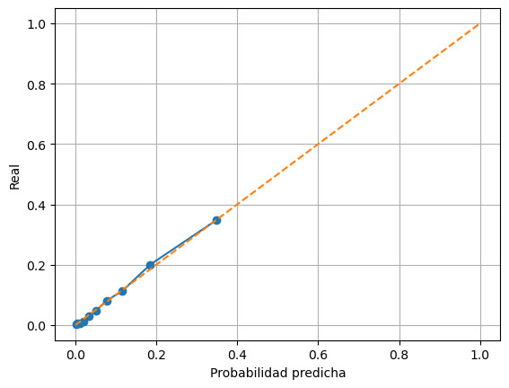

```python
plt.plot(calibracion.probabilidad, calibracion.y, marker="o")
plt.plot([0,1],[0,1],"--")
plt.xlabel("Probabilidad predicha")
plt.ylabel("Real")
plt.grid()
```

La calibracion compara la probabilidad que predice el modelo contra la proporcion que realmente pertenece a la clase 1.

Los valores quedaron bastante cerca de la diagonal. Por ejemplo, en el ultimo grupo el modelo predijo una probabilidad promedio de 0.3492 y la proporcion real fue 0.3485.

En general el modelo polinomial esta bastante bien calibrado, aunque hay pequeñas diferencias en algunos grupos.

## Conclusión

Se compararon los modelos de clasificacion usando AUC porque el target esta desbalanceado y esta metrica permite evaluar que tan bien separa el modelo las dos clases.

Primero revise los datos y vi que solamente 8.5% de las observaciones tienen diabetes. En la exploracion tambien encontre diferencias claras: las personas con diabetes tienen mayor edad promedio, mayor proporcion de hipertension y enfermedad del corazon y un BMI promedio mas alto. Despues converti gender y smoking_history a dummies y dividi los datos en 80% entrenamiento y 20% prueba usando stratify.

Se probaron regresion logistica, KNN, regresion polinomial, Ridge, LDA y red neuronal. El mejor modelo fue la regresion logistica polinomial de grado 2 con un AUC de 0.8402. Muy cerca quedaron la red neuronal con 0.8396, Ridge con 0.8380 y la regresion logistica con 0.8379.

Para intentar mejorar el resultado tambien ajuste KNN usando cross validation. El mejor valor fue k = 50 y su AUC mejoro de 0.7035 a 0.8216, entonces elegir k con validacion cruzada si ayudo bastante, aunque KNN siguio sin superar al modelo polinomial.

Finalmente revise la calibracion del modelo polinomial y las probabilidades predichas quedaron bastante cerca de las proporciones reales.

Por lo tanto me quedaria con el modelo polinomial grado 2, porque fue el que obtuvo el AUC mas alto de todos los modelos que probe.